# Wrangling and Analyzing data

```python
twitter_archive_df['tweet_id'].value_counts()

# the timestamp and retweeted_status_timestamp datatype are object need to change it to datetime ==> Quality
```

```
6.757070e+17    2
8.322160e+17    2
6.737160e+17    2
6.747430e+17    2
6.751470e+17    2
6.675510e+17    2
8.190150e+17    2
7.276860e+17    1
8.347860e+17    1
8.703090e+17    1
7.602530e+17    1
6.671920e+17    1
7.949840e+17    1
6.895170e+17    1
6.709960e+17    1
6.722640e+17    1
7.663130e+17    1
7.490750e+17    1
8.047390e+17    1
6.801910e+17    1
8.344780e+17    1
8.218140e+17    1
7.943320e+17    1
8.732140e+17    1
7.478440e+17    1
7.761130e+17    1
7.087380e+17    1
6.757980e+17    1
8.250270e+17    1
6.997890e+17    1
               ..
8.382020e+17    1
6.849020e+17    1
6.775480e+17    1
8.085020e+17    1
8.186460e+17    1
7.008480e+17    1
6.742710e+17    1
7.910260e+17    1
8.896650e+17    1
6.892750e+17    1
6.895580e+17    1
7.167300e+17    1
6.985500e+17    1
7.840580e+17    1
8.363980e+17    1
8.902400e+17    1
7.050660e+17    1
8.863660e+17    1
7.783830e+17    1
8.918150e+17    1
6.729950e+17    1
8.892790e+17    1
8.874740e+17    1
7.825990e+17    1
8.109850e+17    1
7.519500e+17    1
7.193680e+17    1
6.689920e+17    1
8.889170e+17    1
7.787650e+17    1
Name: tweet_id, Length: 2349, dtype: int64
```

```python
sum(twitter_archive_df['tweet_id'].duplicated())
#remove duplicated
```

```
7
```

```python
twitter_archive_df['rating_denominator'].value_counts()
#remove 11,50,80,20,2,16,40,70,15,90,110,120, 130,150,7,0
#the rating numerators are greater than the denominators does not need to be cleaned
```

```
10     2333
11        3
50        3
80        2
20        2
2         1
16        1
40        1
70        1
15        1
90        1
110       1
120       1
130       1
150       1
170       1
7         1
0         1
Name: rating_denominator, dtype: int64
```

```python
twitter_archive_df['rating_numerator'].value_counts()
# remove all numerator >14
```

```
12      558
11      464
10      461
13      351
9       158
8       102
7        55
14       54
5        37
6        32
3        19
4        17
1         9
2         9
420       2
```

[output cut: 26 more lines]

```python
twitter_archive_df['doggo'].value_counts()
```

```
None     2259
doggo      97
Name: doggo, dtype: int64
```

```python
twitter_archive_df['floofer'].value_counts()
```

```
None       2346
floofer      10
Name: floofer, dtype: int64
```

```python
twitter_archive_df['pupper'].value_counts()
```

```
None      2099
pupper     257
Name: pupper, dtype: int64
```

```python
twitter_archive_df['puppo'].value_counts()
```

```
None     2326
puppo      30
Name: puppo, dtype: int64
```

```python
twitter_archive_df['name'].value_counts()
```

```
None         745
a             55
Charlie       12
Oliver        11
Lucy          11
Cooper        11
Tucker        10
Penny         10
Lola          10
Winston        9
Bo             9
Sadie          8
the            8
Buddy          7
an             7
Bailey         7
Toby           7
Daisy          7
Jack           6
Scout          6
Stanley        6
Jax            6
Milo           6
Leo            6
Bella          6
Oscar          6
Koda           6
Rusty          6
Dave           6
Phil           5
            ...
Rupert         1
Taco           1
Fabio          1
Spark          1
O              1
old            1
Timofy         1
Bauer          1
Clybe          1
Loomis         1
Zeek           1
Freddery       1
Rooney         1
Traviss        1
Mary           1
Callie         1
Jebberson      1
Marvin         1
Pawnd          1
Ember          1
Benny          1
Jameson        1
Darrel         1
Mosby          1
Vixen          1
Oreo           1
Obi            1
Sunshine       1
Koko           1
Danny          1
Name: name, Length: 957, dtype: int64
```

```python
twitter_archive_df['text'].sample(10)
```

```
2082    This is Sage. He likes to burn shit. 10/10 htt...
1177    This is Clyde. He's making sure you're having ...
1196    This is Flávio (pronounced Baxter). He's a Ben...
1302    This is Harper. She scraped her elbow attempti...
1798    Say hello to Chuq. He just wants to fit in. 11...
1867    Good morning here's a grass pupper. 12/10 http...
1997    Lots of pups here. All are Judea Hazelnuts. Ex...
143     This is Paisley. She ate a flower just to prov...
292     This is Daisy. She's puppears to be rare as al...
1891    These two pups are masters of camouflage. Very...
Name: text, dtype: object
```

```python
dog_images_df.head()
#p1 is the algorithm's #1 prediction for the image in the tweet → golden retriever
#p1_conf is how confident the algorithm is in its #1 prediction → 95%
#p1_dog is whether or not the #1 prediction is a breed of dog → TRUE
#p2 is the algorithm's second most likely prediction → Labrador retriever
#p2_conf is how confident the algorithm is in its #2 prediction → 1%
#p2_dog is whether or not the #2 prediction is a breed of dog → TRUE
```

|  | tweet_id | jpg_url | img_num | p1 | p1_conf | p1_dog | p2 | p2_conf | p2_dog | p3 | p3_conf | p3_dog |
| --- | --- | --- | --- | --- | --- | --- | --- | --- | --- | --- | --- | --- |
| 0 | 666020888022790149 | https://pbs.twimg.com/media/CT4udn0WwAA0aMy.jpg | 1 | Welsh_springer_spaniel | 0.465074 | True | collie | 0.156665 | True | Shetland_sheepdog | 0.061428 | True |
| 1 | 666029285002620928 | https://pbs.twimg.com/media/CT42GRgUYAA5iDo.jpg | 1 | redbone | 0.506826 | True | miniature_pinscher | 0.074192 | True | Rhodesian_ridgeback | 0.072010 | True |
| 2 | 666033412701032449 | https://pbs.twimg.com/media/CT4521TWwAEvMyu.jpg | 1 | German_shepherd | 0.596461 | True | malinois | 0.138584 | True | bloodhound | 0.116197 | True |
| 3 | 666044226329800704 | https://pbs.twimg.com/media/CT5Dr8HUEAA-lEu.jpg | 1 | Rhodesian_ridgeback | 0.408143 | True | redbone | 0.360687 | True | miniature_pinscher | 0.222752 | True |
| 4 | 666049248165822465 | https://pbs.twimg.com/media/CT5IQmsXIAAKY4A.jpg | 1 | miniature_pinscher | 0.560311 | True | Rottweiler | 0.243682 | True | Doberman | 0.154629 | True |

```python
dog_images_df.tail()
```

|  | tweet_id | jpg_url | img_num | p1 | p1_conf | p1_dog | p2 | p2_conf | p2_dog | p3 | p3_conf | p3_dog |
| --- | --- | --- | --- | --- | --- | --- | --- | --- | --- | --- | --- | --- |
| 2070 | 891327558926688256 | https://pbs.twimg.com/media/DF6hr6BUMAAzZgT.jpg | 2 | basset | 0.555712 | True | English_springer | 0.225770 | True | German_short-haired_pointer | 0.175219 | True |
| 2071 | 891689557279858688 | https://pbs.twimg.com/media/DF_q7IAWsAEuuN8.jpg | 1 | paper_towel | 0.170278 | False | Labrador_retriever | 0.168086 | True | spatula | 0.040836 | False |
| 2072 | 891815181378084864 | https://pbs.twimg.com/media/DGBdLU1WsAANxJ9.jpg | 1 | Chihuahua | 0.716012 | True | malamute | 0.078253 | True | kelpie | 0.031379 | True |
| 2073 | 892177421306343426 | https://pbs.twimg.com/media/DGGmoV4XsAAUL6n.jpg | 1 | Chihuahua | 0.323581 | True | Pekinese | 0.090647 | True | papillon | 0.068957 | True |
| 2074 | 892420643555336193 | https://pbs.twimg.com/media/DGKD1-bXoAAIAUK.jpg | 1 | orange | 0.097049 | False | bagel | 0.085851 | False | banana | 0.076110 | False |

```python
dog_images_df.shape
#12 coumns and 2075 rows
```

```
(2075, 12)
```

```python
dog_images_df.info()
```

```
<class 'pandas.core.frame.DataFrame'>
RangeIndex: 2075 entries, 0 to 2074
Data columns (total 12 columns):
tweet_id    2075 non-null int64
jpg_url     2075 non-null object
img_num     2075 non-null int64
p1          2075 non-null object
p1_conf     2075 non-null float64
p1_dog      2075 non-null bool
p2          2075 non-null object
p2_conf     2075 non-null float64
p2_dog      2075 non-null bool
p3          2075 non-null object
p3_conf     2075 non-null float64
p3_dog      2075 non-null bool
dtypes: bool(3), float64(3), int64(2), object(4)
memory usage: 152.1+ KB
```

```python
sum(dog_images_df['tweet_id'].duplicated())
```

```
0
```

```python
sum(dog_images_df['jpg_url'].duplicated())
#66 imge duplicated
```

```
66
```

```python
dog_images_df['p1'].value_counts()
```

```
golden_retriever             150
Labrador_retriever           100
Pembroke                      89
Chihuahua                     83
pug                           57
chow                          44
Samoyed                       43
toy_poodle                    39
Pomeranian                    38
malamute                      30
cocker_spaniel                30
French_bulldog                26
Chesapeake_Bay_retriever      23
miniature_pinscher            23
seat_belt                     22
Staffordshire_bullterrier     20
Siberian_husky                20
German_shepherd               20
web_site                      19
Cardigan                      19
Eskimo_dog                    18
Shetland_sheepdog             18
Maltese_dog                   18
beagle                        18
teddy                         18
Rottweiler                    17
Lakeland_terrier              17
Shih-Tzu                      17
Italian_greyhound             16
kuvasz                        16
                            ...
agama                          1
soccer_ball                    1
teapot                         1
banana                         1
marmot                         1
African_grey                   1
park_bench                     1
conch                          1
restaurant                     1
military_uniform               1
hotdog                         1
studio_couch                   1
zebra                          1
lawn_mower                     1
clog                           1
pencil_box                     1
three-toed_sloth               1
rain_barrel                    1
pedestal                       1
four-poster                    1
hare                           1
crane                          1
timber_wolf                    1
convertible                    1
skunk                          1
sliding_door                   1
mortarboard                    1
sulphur-crested_cockatoo       1
bonnet                         1
groenendael                    1
Name: p1, Length: 378, dtype: int64
```

```python
dog_images_df['p2'].value_counts()
```

```
Labrador_retriever                104
golden_retriever                   92
Cardigan                           73
Chihuahua                          44
Pomeranian                         42
French_bulldog                     41
Chesapeake_Bay_retriever           41
toy_poodle                         37
cocker_spaniel                     34
Siberian_husky                     33
miniature_poodle                   33
beagle                             28
Pembroke                           27
Eskimo_dog                         27
collie                             27
kuvasz                             26
Italian_greyhound                  22
Pekinese                           21
American_Staffordshire_terrier     21
malinois                           20
toy_terrier                        20
Samoyed                            20
chow                               20
miniature_pinscher                 20
Boston_bull                        19
Norwegian_elkhound                 19
Staffordshire_bullterrier          18
Irish_terrier                      17
pug                                17
kelpie                             16
                                 ...
pelican                             1
Japanese_spaniel                    1
accordion                           1
hamper                              1
stove                               1
shovel                              1
soccer_ball                         1
hay                                 1
wallaby                             1
hair_slide                          1
bearskin                            1
shopping_cart                       1
otter                               1
cowboy_hat                          1
ashcan                              1
water_bottle                        1
breakwater                          1
maillot                             1
bathing_cap                         1
cliff                               1
police_van                          1
standard_schnauzer                  1
web_site                            1
boathouse                           1
shoji                               1
tree_frog                           1
mailbox                             1
dining_table                        1
assault_rifle                       1
volcano                             1
Name: p2, Length: 405, dtype: int64
```

```python
dog_images_df['p3'].value_counts()
```

```
Labrador_retriever                79
Chihuahua                         58
golden_retriever                  48
Eskimo_dog                        38
kelpie                            35
kuvasz                            34
chow                              32
Staffordshire_bullterrier         32
cocker_spaniel                    31
beagle                            31
Pekinese                          29
Pomeranian                        29
toy_poodle                        29
Pembroke                          27
Great_Pyrenees                    27
Chesapeake_Bay_retriever          27
malamute                          26
French_bulldog                    26
American_Staffordshire_terrier    24
Cardigan                          23
pug                               23
basenji                           21
bull_mastiff                      20
toy_terrier                       20
Siberian_husky                    19
Boston_bull                       17
Shetland_sheepdog                 17
Lakeland_terrier                  16
boxer                             16
doormat                           16
                                  ..
bow_tie                            1
traffic_light                      1
whiptail                           1
bell_cote                          1
croquet_ball                       1
paintbrush                         1
mosquito_net                       1
ox                                 1
black_swan                         1
loggerhead                         1
common_newt                        1
bonnet                             1
moped                              1
Band_Aid                           1
mushroom                           1
Sussex_spaniel                     1
greenhouse                         1
notebook                           1
hare                               1
soap_dispenser                     1
maraca                             1
triceratops                        1
barber_chair                       1
drumstick                          1
nipple                             1
parallel_bars                      1
gorilla                            1
power_drill                        1
lampshade                          1
chimpanzee                         1
Name: p3, Length: 408, dtype: int64
```

```python
twitter_feed_df.head()
```

|  | tweet_id | text | favorite_count | retweet_count |
| --- | --- | --- | --- | --- |
| 0 | 666020888022790149 | Here we have a Japanese Irish Setter. Lost eye... | 2529 | 498 |
| 1 | 666029285002620928 | This is a western brown Mitsubishi terrier. Up... | 125 | 46 |
| 2 | 666033412701032449 | Here is a very happy pup. Big fan of well-main... | 123 | 43 |
| 3 | 666044226329800704 | This is a purebred Piers Morgan. Loves to Netf... | 292 | 136 |
| 4 | 666049248165822465 | Here we have a 1949 1st generation vulpix. Enj... | 106 | 42 |

```python
twitter_feed_df.tail()
```

|  | tweet_id | text | favorite_count | retweet_count |
| --- | --- | --- | --- | --- |
| 2062 | 891327558926688256 | This is Franklin. He would like you to stop ca... | 39397 | 9110 |
| 2063 | 891689557279858688 | This is Darla. She commenced a snooze mid meal... | 41219 | 8411 |
| 2064 | 891815181378084864 | This is Archie. He is a rare Norwegian Pouncin... | 24493 | 4042 |
| 2065 | 892177421306343426 | This is Tilly. She's just checking pup on you.... | 32532 | 6106 |
| 2066 | 892420643555336193 | This is Phineas. He's a mystical boy. Only eve... | 37862 | 8262 |

```python
twitter_feed_df.info()
```

```
<class 'pandas.core.frame.DataFrame'>
RangeIndex: 2067 entries, 0 to 2066
Data columns (total 4 columns):
tweet_id          2067 non-null object
text              2067 non-null object
favorite_count    2067 non-null int64
retweet_count     2067 non-null int64
dtypes: int64(2), object(2)
memory usage: 64.7+ KB
```

```python
sum(twitter_feed_df['tweet_id'].duplicated())
```

```
0
```

```python
twitter_feed_df.retweet_count.sample()
```

```
1568    2518
Name: retweet_count, dtype: int64
```

```python
twitter_feed_df.favorite_count.sample()
```

```
331    2430
Name: favorite_count, dtype: int64
```

```python
shape_a = twitter_archive_df.shape
shape_b = twitter_feed_df.shape
shape_c = dog_images_df.shape
print(shape_a,shape_b,shape_c)
```

```
(2356, 18) (2067, 4) (2075, 12)
```

```python
#check id datatype before merging the dataframes into one
a = twitter_archive_df['tweet_id'].dtype
b = dog_images_df['tweet_id'].dtype
c = twitter_feed_df['tweet_id'].dtype
print(a,b,c)
```

```
float64 int64 object
```

### Tidness Issues:

#### Define:

- Merge all dataframes together
- jpg_url contins duplicated urls.
- There are four different columns of gog stages (Doggo, flooder, popper and puppy) merge it into one column and remove nulls.
- Text (tweets) contains #, extract the hashtages from the text column and store it in tweet_hashtag column.
- Calculate the rating in new column and store the percentage value.
- Combine puppo, floofer, doggo, and pupper into one column 'dog_stages'

## Cleaning data

In this step, I cleand most of issues.

```python
#Make a copy of the dataframes
twitter_archive_df_copy = twitter_archive_df.copy()
dog_images_df_copy = dog_images_df.copy()
twitter_feed_df_copy = twitter_feed_df.copy()
```

#### Change tweeet_id to String

```python
twitter_archive_df_copy['tweet_id'] = twitter_archive_df_copy.tweet_id.astype(str)
```

```python
twitter_archive_df_copy.tweet_id.dtype
```

```
dtype('O')
```

```python
dog_images_df_copy['tweet_id'] = dog_images_df_copy.tweet_id .astype(str)
```

```python
dog_images_df_copy.tweet_id.dtype
```

```
dtype('O')
```

```python
twitter_feed_df_copy['tweet_id'].dtype
```

```
dtype('O')
```

#### Remove duplicates from twitter_archive_df_copy

#### Code

```python
twitter_archive_df_copy.drop_duplicates(keep = False, inplace = True)
```

#### Test

```python
sum(twitter_archive_df_copy.duplicated())
```

```
0
```

##### Timestamp in twitter_archive_df is object, change it to datetime type

##### Code

```python
#Change the timestamp to datetime
twitter_archive_df_copy['timestamp'] = pd.to_datetime(twitter_archive_df_copy['timestamp'], format ='%Y-%m-%d')
#'%Y-%m-%d'
```

##### Test

```python
#check
twitter_archive_df_copy['timestamp'].dtype
```

```
dtype('<M8[ns]')
```

```python
twitter_archive_df_copy['timestamp'].head(5)
```

```
0   2017-08-01 16:23:56
1   2017-08-01 00:17:27
2   2017-07-31 00:18:03
3   2017-07-30 15:58:51
4   2017-07-29 16:00:24
Name: timestamp, dtype: datetime64[ns]
```

#### Split timestamp to date (year-month-day)

```python
#date
twitter_archive_df_copy['date'] = pd.to_datetime(twitter_archive_df_copy['timestamp']).dt.date
twitter_archive_df_copy['date'] = pd.to_datetime(twitter_archive_df_copy['date'], format ='%Y-%m-%d')
```

```python
twitter_archive_df_copy['year'] = pd.DatetimeIndex(twitter_archive_df_copy['date']).year
```

```python
twitter_archive_df_copy['month'] = pd.DatetimeIndex(twitter_archive_df_copy['date']).month
```

```python
twitter_archive_df_copy['day'] = pd.DatetimeIndex(twitter_archive_df_copy['date']).day
```

```python
#drop ==>timestamp
twitter_archive_df_copy = twitter_archive_df_copy.drop(['timestamp'], axis=1)
```

#### Test

```python
twitter_archive_df_copy.year.head()
```

```
0    2017
1    2017
2    2017
3    2017
4    2017
Name: year, dtype: int64
```

```python
twitter_archive_df_copy.month.head()
```

```
0    8
1    8
2    7
3    7
4    7
Name: month, dtype: int64
```

```python
twitter_archive_df_copy.day.head()
```

```
0     1
1     1
2    31
3    30
4    29
Name: day, dtype: int64
```

##### Text (tweets) contains #, extract the hashtages from the text column and store it in tweet_hashtag column.

##### Code

```python
#create new column "tweet_hashtag" to get all hashtages from text
twitter_archive_df_copy['tweet_hashtag'] = twitter_archive_df_copy['text'].str.extract(r"#(\w+)")
```

##### Test

```python
twitter_archive_df_copy['tweet_hashtag'].value_counts()
#used hashtages
```

```
BarkWeek                 9
PrideMonth               3
Canada150                1
PrideMonthPuppo          1
ScienceMarch             1
GoodDogs                 1
WKCDogShow               1
NoDaysOff                1
ImWithThor               1
notallpuppers            1
dogsatpollingstations    1
BATP                     1
WomensMarch              1
BellLetsTalk             1
LoveTwitter              1
FinalFur                 1
K9VeteransDay            1
Name: tweet_hashtag, dtype: int64
```

##### Remove any denominator does not equal 10 (1,50,80,20,2,16,40,70,15,90,110,120, 130,150,7,0)

##### Code

```python
#to get rate of dogs I removed any denominator does not equal 10
twitter_archive_df_copy = twitter_archive_df_copy[twitter_archive_df_copy['rating_denominator']==10]
```

##### Test

```python
twitter_archive_df_copy['rating_denominator'].value_counts()
```

```
10    2333
Name: rating_denominator, dtype: int64
```

##### Remove outlires from nominator column.

##### Code

```python
#np.where(twitter_archive_df_copy['rating_numerator'] > 14)
twitter_archive_df_copy[twitter_archive_df_copy.text.str.contains(r"(\d+\.\d*\/\d+)")][['text', 'rating_numerator']]
```

|  | text | rating_numerator |
| --- | --- | --- |
| 45 | This is Bella. She hopes her smile made you sm... | 5 |
| 340 | RT @dog_rates: This is Logan, the Chow who liv... | 75 |
| 695 | This is Logan, the Chow who lived. He solemnly... | 75 |
| 763 | This is Sophie. She's a Jubilant Bush Pupper. ... | 27 |
| 1689 | I've been told there's a slight possibility he... | 5 |
| 1712 | Here we have uncovered an entire battalion of ... | 26 |

```python
twitter_archive_df_copy = twitter_archive_df_copy.drop([45,1689,340,695,763,1712], axis=0)
```

```python
twitter_archive_df_copy = twitter_archive_df_copy[twitter_archive_df_copy['rating_numerator']<14]
```

```python
twitter_archive_df_copy.rating_numerator = twitter_archive_df_copy['rating_numerator'].astype(float)
```

```python
twitter_archive_df_copy.rating_numerator.dtype
```

```
dtype('float64')
```

##### Test

```python
twitter_archive_df_copy['rating_numerator'].value_counts()
```

```
12.0    558
11.0    463
10.0    461
13.0    351
9.0     156
8.0     102
7.0      54
5.0      35
6.0      32
3.0      19
4.0      15
2.0       9
1.0       8
0.0       2
Name: rating_numerator, dtype: int64
```

##### Calculate the rating in new column and store the percentage value in new column

##### Code

```python
# Calculate the rating
twitter_archive_df_copy['rating'] = (twitter_archive_df_copy['rating_numerator'] / twitter_archive_df['rating_denominator'])*100
```

##### Test

```python
twitter_archive_df_copy['rating'].value_counts()
```

```
120.0    558
110.0    463
100.0    461
130.0    351
90.0     156
80.0     102
70.0      54
50.0      35
60.0      32
30.0      19
40.0      15
20.0       9
10.0       8
0.0        2
Name: rating, dtype: int64
```

```python
twitter_archive_df_copy['rating'].sample()
```

```
58    130.0
Name: rating, dtype: float64
```

##### Replace None to NAN in Name, doggo, floofer, pupper and puppo columns

##### Code

```python
#Name
twitter_archive_df_copy['name'].replace('None', np.nan, inplace=True)
#Doggo
twitter_archive_df_copy['doggo'].replace('None', np.nan, inplace=True)
#flooder
twitter_archive_df_copy['floofer'].replace('None', np.nan, inplace=True)
#popper
twitter_archive_df_copy['pupper'].replace('None', np.nan, inplace=True)
#puppy
twitter_archive_df_copy['puppo'].replace('None', np.nan, inplace=True)
```

##### Test

```python
twitter_archive_df_copy['puppo'].value_counts()
```

```
puppo    29
Name: puppo, dtype: int64
```

```python
twitter_archive_df_copy['floofer'].value_counts()
```

```
floofer    10
Name: floofer, dtype: int64
```

```python
twitter_archive_df_copy['doggo'].value_counts()
```

```
doggo    87
Name: doggo, dtype: int64
```

```python
twitter_archive_df_copy['pupper'].value_counts()
```

```
pupper    248
Name: pupper, dtype: int64
```

##### Remove unused names from name and make the first letter capital.

##### Code

```python
twitter_archive_df_copy.name.value_counts()
```

```
a            53
Charlie      12
Lucy         11
Cooper       11
Oliver       11
Penny        10
Tucker       10
Lola         10
Winston       9
the           8
Sadie         8
Toby          7
Buddy         7
Bo            7
Daisy         7
Bailey        7
Jax           6
Jack          6
Dave          6
Koda          6
an            6
Stanley       6
Oscar         6
Scout         6
Milo          6
Rusty         6
Leo           6
very          5
Phil          5
Larry         5
             ..
Fabio         1
Spark         1
O             1
Philippe      1
Boston        1
Winifred      1
old           1
Loomis        1
Pawnd         1
Zeek          1
Freddery      1
Rooney        1
Traviss       1
Mary          1
Callie        1
Jebberson     1
Marvin        1
Clybe         1
Coleman       1
Kallie        1
Jameson       1
Mosby         1
Vixen         1
Oreo          1
Obi           1
Sunshine      1
Koko          1
Ember         1
Timofy        1
Danny         1
Name: name, Length: 941, dtype: int64
```

```python
#remove and replace letters or symbols from name column manully
#lower case and <4 "Condition"

#1 . find all lower case names
#2 . find all names with len <4
#4 . replace nonnames with NAN
#5 . remove null names

change_name = []
for names in twitter_archive_df_copy.name:
    if len(str(names)) <= 3 and str(names).islower():
        change_name.append(names)
```

##### Test

```python
twitter_archive_df_copy.name.replace(change_name,np.nan,inplace = True)
```

```python
twitter_archive_df_copy.name.value_counts()
```

```
Charlie      12
Cooper       11
Oliver       11
Lucy         11
Lola         10
Tucker       10
Penny        10
Winston       9
Sadie         8
Toby          7
Bailey        7
Buddy         7
Bo            7
Daisy         7
Leo           6
Stanley       6
Rusty         6
Jack          6
Jax           6
Scout         6
Oscar         6
Dave          6
Milo          6
Koda          6
George        5
Louis         5
Finn          5
Bella         5
Oakley        5
Sammy         5
             ..
Rupert        1
Taco          1
Bode          1
Spark         1
O             1
Timofy        1
Koko          1
Harlso        1
Callie        1
Ace           1
Nida          1
Bauer         1
Loomis        1
Zeek          1
Freddery      1
Rooney        1
Traviss       1
Mary          1
Jebberson     1
Sunshine      1
Marvin        1
Clybe         1
Pawnd         1
Coleman       1
Jameson       1
Mosby         1
Vixen         1
Oreo          1
Obi           1
Danny         1
Name: name, Length: 930, dtype: int64
```

##### Delete the columns that I don't use it.

##### Code

```python
list(twitter_archive_df_copy)
#remove ==> in_reply_to_status_id','in_reply_to_user_id','#VALUE!',source
```

```
['tweet_id',
 'in_reply_to_status_id',
 'in_reply_to_user_id',
 'source',
 'text',
 'retweeted_status_id',
 'retweeted_status_user_id',
 'retweeted_status_timestamp',
 'expanded_urls',
 'rating_numerator',
 'rating_denominator',
 'name',
 'doggo',
 'floofer',
 'pupper',
 'puppo',
 '#VALUE!',
 'date',
 'year',
 'month',
 'day',
 'tweet_hashtag',
 'rating']
```

```python
list(dog_images_df_copy)
#remove ==> img_num
```

```
['tweet_id',
 'jpg_url',
 'img_num',
 'p1',
 'p1_conf',
 'p1_dog',
 'p2',
 'p2_conf',
 'p2_dog',
 'p3',
 'p3_conf',
 'p3_dog']
```

```python
list (twitter_feed_df_copy)
```

```
['tweet_id', 'text', 'favorite_count', 'retweet_count']
```

```python
twitter_archive_df_copy.drop(['in_reply_to_status_id','in_reply_to_user_id','source','#VALUE!'], axis=1, inplace=True)
```

```python
dog_images_df_copy.drop(['img_num'], axis=1, inplace=True)
```

##### Test

```python
list(twitter_archive_df_copy)
```

```
['tweet_id',
 'text',
 'retweeted_status_id',
 'retweeted_status_user_id',
 'retweeted_status_timestamp',
 'expanded_urls',
 'rating_numerator',
 'rating_denominator',
 'name',
 'doggo',
 'floofer',
 'pupper',
 'puppo',
 'date',
 'year',
 'month',
 'day',
 'tweet_hashtag',
 'rating']
```

```python
list(dog_images_df_copy)
```

```
['tweet_id',
 'jpg_url',
 'p1',
 'p1_conf',
 'p1_dog',
 'p2',
 'p2_conf',
 'p2_dog',
 'p3',
 'p3_conf',
 'p3_dog']
```

##### Remove retweets and keeps tweets

##### Code

```python
#when the retweeted_status_id column equal null (nan) means this is tweet not retweet
twitter_archive_df_copy= twitter_archive_df_copy[twitter_archive_df_copy['retweeted_status_id'].isnull()]
```

##### Test

```python
print(twitter_archive_df_copy.info())
```

```
<class 'pandas.core.frame.DataFrame'>
Int64Index: 2098 entries, 0 to 2355
Data columns (total 19 columns):
tweet_id                      2098 non-null object
text                          2098 non-null object
retweeted_status_id           0 non-null float64
retweeted_status_user_id      0 non-null float64
retweeted_status_timestamp    0 non-null object
expanded_urls                 2053 non-null object
rating_numerator              2098 non-null float64
rating_denominator            2098 non-null int64
name                          1388 non-null object
doggo                         79 non-null object
floofer                       10 non-null object
pupper                        226 non-null object
puppo                         24 non-null object
date                          2098 non-null datetime64[ns]
year                          2098 non-null int64
month                         2098 non-null int64
day                           2098 non-null int64
tweet_hashtag                 22 non-null object
rating                        2098 non-null float64
dtypes: datetime64[ns](1), float64(4), int64(4), object(10)
memory usage: 327.8+ KB
None
```

##### Combine puppo, floofer, doggo, and pupper into one column 'dog_stages'

##### Code

```python
#extract dog stage from tweet text and store it into gog_stage cloumn
#twitter_archive_df_copy['dog_stage'] = twitter_archive_df_copy['text'].str.extract('(doggo|floofer|pupper|puppo)')

dog_stage=[]
dog_stage_1 = ['doggo', 'floofer', 'pupper', 'puppo']
dog_stage_2 = ['doggo', 'floofer', 'pupper', 'puppo']

for read in twitter_archive_df_copy['text']:
    read = read.lower()
    for dog_type in dog_stage_1:
        if dog_type in str(read):
            dog_stage.append(dog_stage_2[dog_stage_1.index(dog_type)])
            break
    else:
        dog_stage.append('None')

twitter_archive_df_copy['dog_stage'] = dog_stage
```

```python
#Multiple dog_stage in one tweet
twitter_archive_df_copy[twitter_archive_df_copy.dog_stage == 'doggofloofer'].head()
twitter_archive_df_copy.loc[twitter_archive_df_copy.dog_stage == 'doggofloofer', 'dog_stage'] = 'doggo,floofer'
```

```python
twitter_archive_df_copy[twitter_archive_df_copy.dog_stage == 'doggopuppo'].head()
twitter_archive_df_copy.loc[twitter_archive_df_copy.dog_stage == 'doggopuppo', 'dog_stage'] = 'doggo,puppo'
```

```python
twitter_archive_df_copy[twitter_archive_df_copy.dog_stage == 'doggopupper'].head()
twitter_archive_df_copy.loc[twitter_archive_df_copy.dog_stage == 'doggopupper', 'dog_stage'] = 'doggo,pupper'
```

##### Test

```python
twitter_archive_df_copy.dog_stage.value_counts()
```

```
None       1741
pupper      234
doggo        84
puppo        30
floofer       9
Name: dog_stage, dtype: int64
```

```python
twitter_archive_df_copy['dog_stage'].replace('None', np.nan, inplace=True)
#Missing values
```

```python
#drop null values from dog stage column
twitter_archive_df_copy.dog_stage = twitter_archive_df_copy.dog_stage.dropna()
```

```python
twitter_archive_df_copy.dog_stage.value_counts()
```

```
pupper     234
doggo       84
puppo       30
floofer      9
Name: dog_stage, dtype: int64
```

```python
#drop 'doggo', 'floofer', 'pupper', 'puppo' columns
twitter_archive_df_copy = twitter_archive_df_copy.drop(['doggo', 'floofer', 'pupper', 'puppo'], axis=1)
```

```python
list(twitter_archive_df_copy)
```

```
['tweet_id',
 'text',
 'retweeted_status_id',
 'retweeted_status_user_id',
 'retweeted_status_timestamp',
 'expanded_urls',
 'rating_numerator',
 'rating_denominator',
 'name',
 'date',
 'year',
 'month',
 'day',
 'tweet_hashtag',
 'rating',
 'dog_stage']
```

#### Merge all dataframes into one

#### Code

```python
#dog_images_df_copy.set_index('tweet_id')
#twitter_archive_df_copy.set_index('tweet_id')
#twitter_feed_df_copy.set_index('tweet_id')
```

```python
#twitter = pd.merge(dog_images_df_copy, twitter_feed_df_copy,how='outer',left_on='tweet_id', right_on='tweet_id')
final_twitter_data = dog_images_df_copy.merge(twitter_archive_df_copy,how = 'outer',left_on = 'tweet_id', right_on = 'tweet_id')
```

```python
final_twitter_data = final_twitter_data.merge(twitter_feed_df_copy,how = 'outer',left_on = 'tweet_id', right_on = 'tweet_id')
```

#### Test

```python
final_twitter_data.head(3)
```

|  | tweet_id | jpg_url | p1 | p1_conf | p1_dog | p2 | p2_conf | p2_dog | p3 | p3_conf | ... | date | year | month | day | tweet_hashtag | rating | dog_stage | text_y | favorite_count | retweet_count |
| --- | --- | --- | --- | --- | --- | --- | --- | --- | --- | --- | --- | --- | --- | --- | --- | --- | --- | --- | --- | --- | --- |
| 0 | 666020888022790149 | https://pbs.twimg.com/media/CT4udn0WwAA0aMy.jpg | Welsh_springer_spaniel | 0.465074 | True | collie | 0.156665 | True | Shetland_sheepdog | 0.061428 | ... | NaT | NaN | NaN | NaN | NaN | NaN | NaN | Here we have a Japanese Irish Setter. Lost eye... | 2529.0 | 498.0 |
| 1 | 666029285002620928 | https://pbs.twimg.com/media/CT42GRgUYAA5iDo.jpg | redbone | 0.506826 | True | miniature_pinscher | 0.074192 | True | Rhodesian_ridgeback | 0.072010 | ... | NaT | NaN | NaN | NaN | NaN | NaN | NaN | This is a western brown Mitsubishi terrier. Up... | 125.0 | 46.0 |
| 2 | 666033412701032449 | https://pbs.twimg.com/media/CT4521TWwAEvMyu.jpg | German_shepherd | 0.596461 | True | malinois | 0.138584 | True | bloodhound | 0.116197 | ... | NaT | NaN | NaN | NaN | NaN | NaN | NaN | Here is a very happy pup. Big fan of well-main... | 123.0 | 43.0 |

3 rows × 29 columns

#### Store merged dataframes into csv file

```python
list(final_twitter_data)
```

```
['tweet_id',
 'jpg_url',
 'p1',
 'p1_conf',
 'p1_dog',
 'p2',
 'p2_conf',
 'p2_dog',
 'p3',
 'p3_conf',
 'p3_dog',
 'text_x',
 'retweeted_status_id',
 'retweeted_status_user_id',
 'retweeted_status_timestamp',
 'expanded_urls',
 'rating_numerator',
 'rating_denominator',
 'name',
 'date',
 'year',
 'month',
 'day',
 'tweet_hashtag',
 'rating',
 'dog_stage',
 'text_y',
 'favorite_count',
 'retweet_count']
```

```python
final_twitter_data.to_csv('twitter_archive_master.csv')
```

## Storing, Analyzing, and Visualizing

```python
#read twitter_data_df from csv file

final_twitter_data = pd.read_csv('twitter_archive_master.csv')
```

```python
final_twitter_data.sample()
```

|  | Unnamed: 0 | tweet_id | jpg_url | p1 | p1_conf | p1_dog | p2 | p2_conf | p2_dog | p3 | ... | date | year | month | day | tweet_hashtag | rating | dog_stage | text_y | favorite_count | retweet_count |
| --- | --- | --- | --- | --- | --- | --- | --- | --- | --- | --- | --- | --- | --- | --- | --- | --- | --- | --- | --- | --- | --- |
| 1375 | 1375 | 7.631035e+17 | https://pbs.twimg.com/media/CpcWknPXYAAeLP9.jpg | seat_belt | 0.685821 | False | ice_bear | 0.081597 | False | chow | ... | NaN | NaN | NaN | NaN | NaN | NaN | NaN | This is Belle. She's a Butterflop Hufflepoof. ... | 7758.0 | 2457.0 |

1 rows × 30 columns

```python
final_twitter_data = final_twitter_data.drop(['Unnamed: 0'], axis=1)
```

### The Relation of tetweet_count and favorite_count

```
Text(0.5,1,'Relation of tetweet_count and favorite_count')
```

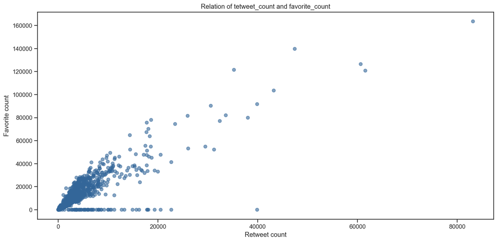

```python
#### Relation between value count and favorite_count
fig, ax = plt.subplots(figsize=(15,7))
plt.scatter(final_twitter_data['retweet_count'], final_twitter_data['favorite_count'],color=(0.2, 0.4, 0.6, 0.6))
plt.xlabel('Retweet count')
plt.ylabel('Favorite count')
plt.title('Relation of tetweet_count and favorite_count')
```

```python
final_twitter_data.retweet_count.describe()
```

```
count     2067.000000
mean      2785.600871
std       4847.954213
min         11.000000
25%        593.000000
50%       1312.000000
75%       3212.500000
max      83162.000000
Name: retweet_count, dtype: float64
```

```python
final_twitter_data.favorite_count.describe()
```

```
count      2067.000000
mean       8375.003870
std       12618.469168
min           0.000000
25%        1591.500000
50%        3680.000000
75%       10471.000000
max      163574.000000
Name: favorite_count, dtype: float64
```

### Which tweet have the highest retweet and favorite count

```python
final_twitter_data[final_twitter_data['retweet_count']==final_twitter_data['retweet_count'].max()]
#ret max is 83162
```

|  | tweet_id | jpg_url | p1 | p1_conf | p1_dog | p2 | p2_conf | p2_dog | p3 | p3_conf | ... | date | year | month | day | tweet_hashtag | rating | dog_stage | text_y | favorite_count | retweet_count |
| --- | --- | --- | --- | --- | --- | --- | --- | --- | --- | --- | --- | --- | --- | --- | --- | --- | --- | --- | --- | --- | --- |
| 1221 | 7.442348e+17 | https://pbs.twimg.com/ext_tw_video_thumb/74423... | Labrador_retriever | 0.825333 | True | ice_bear | 0.044681 | False | whippet | 0.018442 | ... | NaN | NaN | NaN | NaN | NaN | NaN | NaN | Here's a doggo realizing you can stand in a po... | 163574.0 | 83162.0 |

1 rows × 29 columns

```python
#fav max is 163574
final_twitter_data[final_twitter_data['favorite_count']==final_twitter_data['favorite_count'].max()]
```

|  | tweet_id | jpg_url | p1 | p1_conf | p1_dog | p2 | p2_conf | p2_dog | p3 | p3_conf | ... | date | year | month | day | tweet_hashtag | rating | dog_stage | text_y | favorite_count | retweet_count |
| --- | --- | --- | --- | --- | --- | --- | --- | --- | --- | --- | --- | --- | --- | --- | --- | --- | --- | --- | --- | --- | --- |
| 1221 | 7.442348e+17 | https://pbs.twimg.com/ext_tw_video_thumb/74423... | Labrador_retriever | 0.825333 | True | ice_bear | 0.044681 | False | whippet | 0.018442 | ... | NaN | NaN | NaN | NaN | NaN | NaN | NaN | Here's a doggo realizing you can stand in a po... | 163574.0 | 83162.0 |

1 rows × 29 columns

### The correlation between retweet_count and favorite_count columns

```python
final_twitter_data.favorite_count.corr(final_twitter_data.retweet_count)
```

```
0.8566013476421317
```

It is high corrletion between retweet and like tweets

### Most dog stages

```
Text(3.925,0.5,'Counts')
```

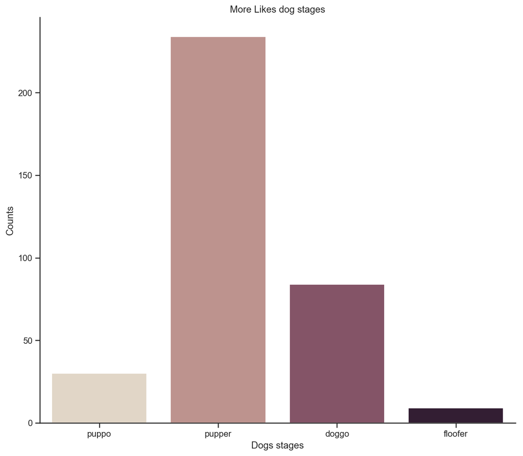

```python
sns.catplot(x="dog_stage", kind="count", palette="ch:.25", data=final_twitter_data,height=8, aspect=8/7)
plt.title('More Likes dog stages')
plt.xlabel('Dogs stages')
plt.ylabel('Counts')
```

### Count of Tweet Hashtags

```
Text(-80.575,0.5,'Counts')
```

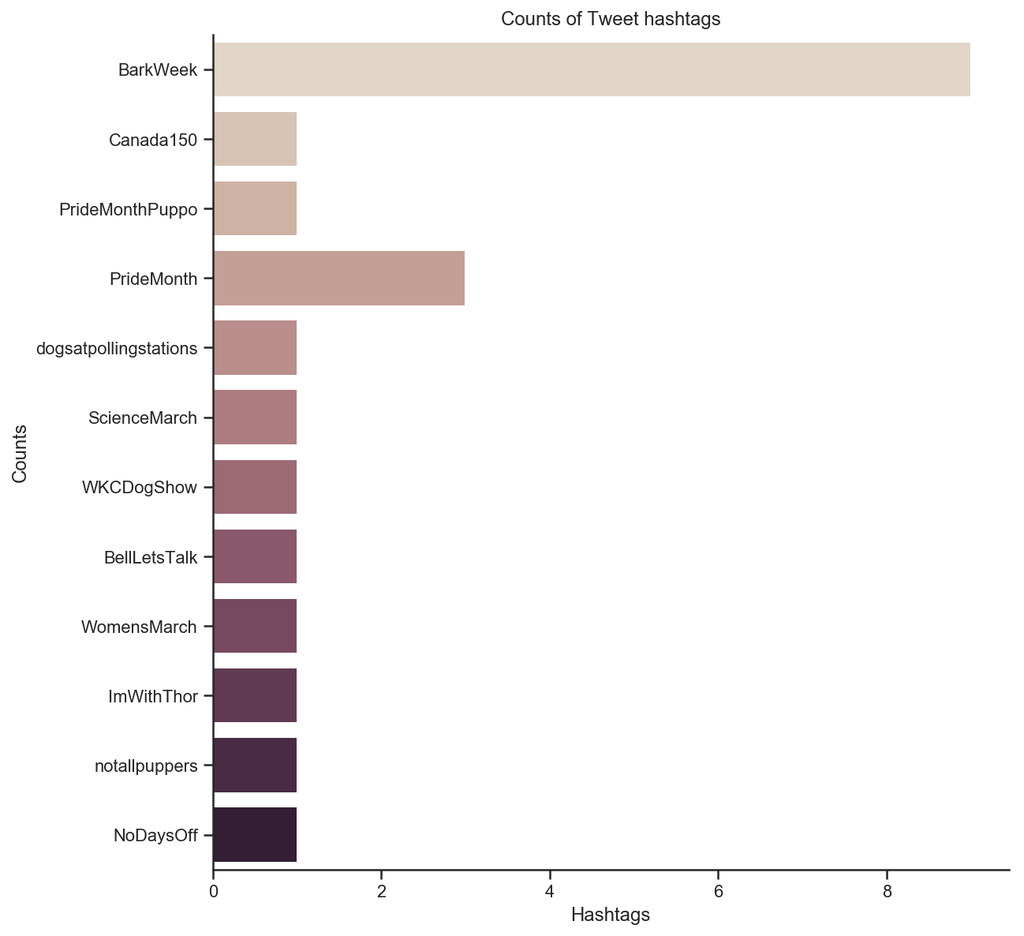

```python
sns.catplot(y="tweet_hashtag", kind="count", palette="ch:.25", data=final_twitter_data, height=8, aspect=8/7)
plt.title('Counts of Tweet hashtags')
plt.xlabel('Hashtags')
plt.ylabel('Counts')
```

### The dog stage's rating in years

```
Text(0.5,0,'Dog stages in Years')
```

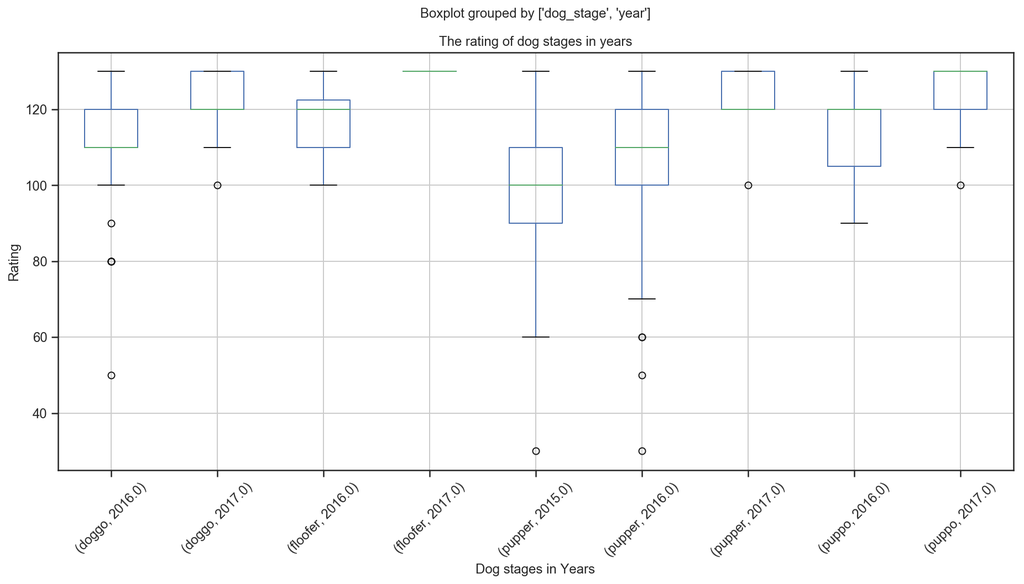

```python
final_twitter_data.boxplot(column=['rating'], by=['dog_stage', 'year'],rot=45, fontsize=12,figsize=(15,7))
plt.title('The rating of dog stages in years')
plt.ylabel('Rating')
plt.xlabel('Dog stages in Years')
```

```python
final_twitter_data.groupby('dog_stage')['rating'].describe()
```

| dog_stage | count | mean | std | min | 25% | 50% | 75% | max |
| --- | --- | --- | --- | --- | --- | --- | --- | --- |
| doggo | 84.0 | 114.523810 | 14.759499 | 50.0 | 110.0 | 120.0 | 130.0 | 130.0 |
| floofer | 9.0 | 118.888889 | 10.540926 | 100.0 | 110.0 | 120.0 | 130.0 | 130.0 |
| pupper | 234.0 | 105.811966 | 17.394159 | 30.0 | 100.0 | 110.0 | 120.0 | 130.0 |
| puppo | 30.0 | 119.666667 | 11.885469 | 90.0 | 112.5 | 120.0 | 130.0 | 130.0 |

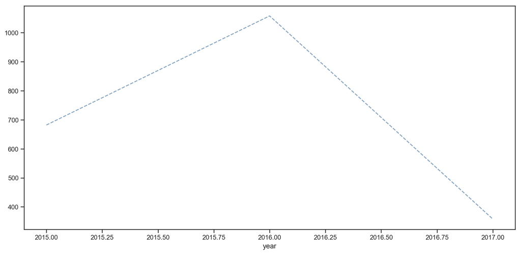

```python
#The relation between dog rating over years
fig, ax = plt.subplots(figsize=(15,7))
final_twitter_data.groupby(['year'])['rating'].count().plot(ax=ax,color=(0.2, 0.4, 0.6, 0.6),linestyle='--')
```

## Acknowledgement

- https://pandas.pydata.org/pandas-docs/stable/reference/api/pandas.DataFrame.set_index.html
- https://stackoverflow.com/questions/2527892/parsing-a-tweet-to-extract-hashtags-into-an-array-in-python
- https://stackoverflow.com/questions/36108377/how-to-use-the-split-function-on-every-row-in-a-dataframe-in-python
- https://stackoverflow.com/questions/23743460/replace-none-with-nan-in-pandas-dataframe
- https://www.toptal.com/python/twitter-data-mining-using-python
- https://pandas.pydata.org/pandas-docs/version/0.20/generated/pandas.melt.html
- https://www.geeksforgeeks.org/python-pandas-melt/
- https://stackoverflow.com/questions/12934997/how-to-detect-lowercase-letters-in-python
- https://stackoverflow.com/questions/21011777/how-can-i-remove-nan-from-list-python-numpy
- https://stackoverflow.com/questions/23668427/pandas-three-way-joining-multiple-dataframes-on-columns
- https://pandas.pydata.org/pandas-docs/stable/user_guide/merging.html
- https://pandas.pydata.org/pandas-docs/stable/reference/api/pandas.DataFrame.boxplot.html